# Disease Surveillance Report - DEMO VERSION

# Reportable Disease: Legionellosis

## Introduction

Legionellosis, also known as Legionnaire’s disease, is a pneumonia caused by Legionella bacteria. People with legionellosis often have flu-like symptoms, with muscle aches, headache, loss of appetite, dry cough, and fever. It is more common in the elderly and those with underlying disease. People get legionellosis by breathing in the Legionella bacteria, usually carried by a mist or aerosol. The bacteria are found normally in many places in the environment, especially warm stagnant water. Outbreaks have been related to contaminated air-conditioning cooling towers.

### More Information:

[Current Case Definition](http://www.maventrainingsite.com/maven-help/pdf/case-classification-manual/LEGIONELLOSIS_%2008222017.pdf)

[MDPH Disease Fact Sheet](https://www.mass.gov/service-details/legionellosis-legionnaires-disease)

## Geography

Legionella is widely distributed across the state with at least 1 confirmed case in every city/town over the past 10 years. This interactive map displays counts of confirmed cases by official city/town in Massachusetts between 2007 and 2016. Click on a town to see the total confirmed cases for that town.

[interactive chart not shown]

## Health Care Setting

Legionella is primarily community acquired with a few known cases associated with healthcare settings. Breathing in bacteria from mist dispersed by cooling towers has been associated with outbreaks.

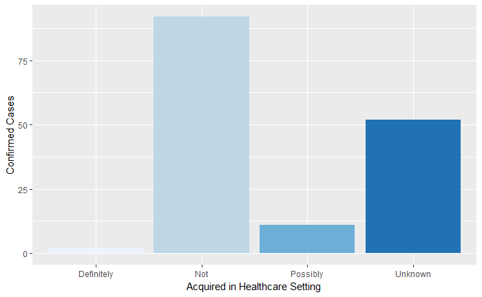

## Age and Gender

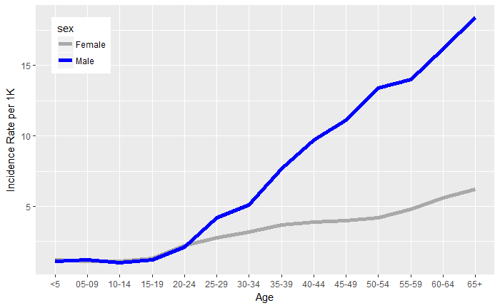

## Exposure Setting

Confirmed Legionella cases reported in MA are primarily the result of exposure within the state and a large proportion with unknown exposure setting. A small number of confirmed cases living in MA were exposed outside MA or outside the US.

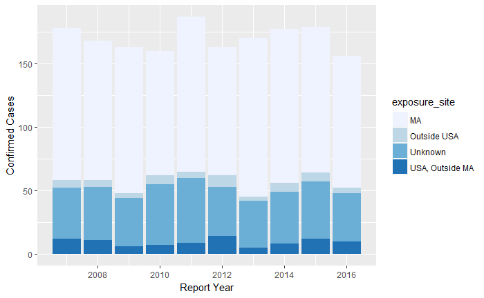

## Footnotes

Official City could not be found for (N=23) confirmed cases

Source: Bureau of Infectious Disease and Laboratory Sciences, Office of Integrated Surveillance & Informatics Services